# Salinas Union High Dashboard DA Summary

## Report Purpose

This report is created to synthesize information to assist Salinas Union High in reflecting on the student groups for whom indicators led to Differentiated Assistance.

## Latest Status by Group

The graphic below shows the color for each student group for each indicator for which a color was generated by the dashboard. This reflects the latest available colors from the 2022 dashboard.

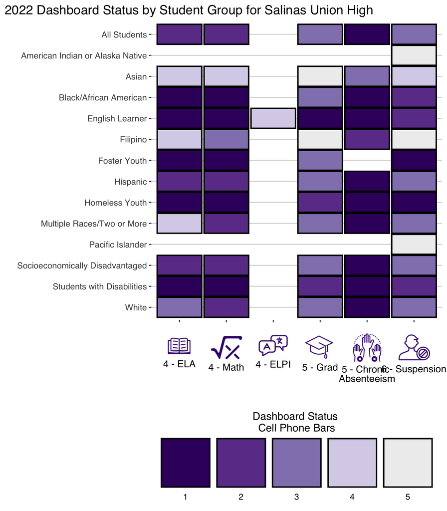

## Qualifying Groups

This table displays which student groups qualified the district to be eligible for [Differentiated Assistance](https://www.cde.ca.gov/ta/ac/cm/leaproposedcrit.asp). Moreover, for each student group it shows which Priority Areas and associated indicator criteria for which the student group qualifies.

As a reminder, COEs must offer differentiated assistance to a school district if any student group meets the criteria for two or more LCFF priorities according to California Education Code Section 52071(c). [California’s System of Support](https://www.cde.ca.gov/sp/sw/t1/csss.asp)

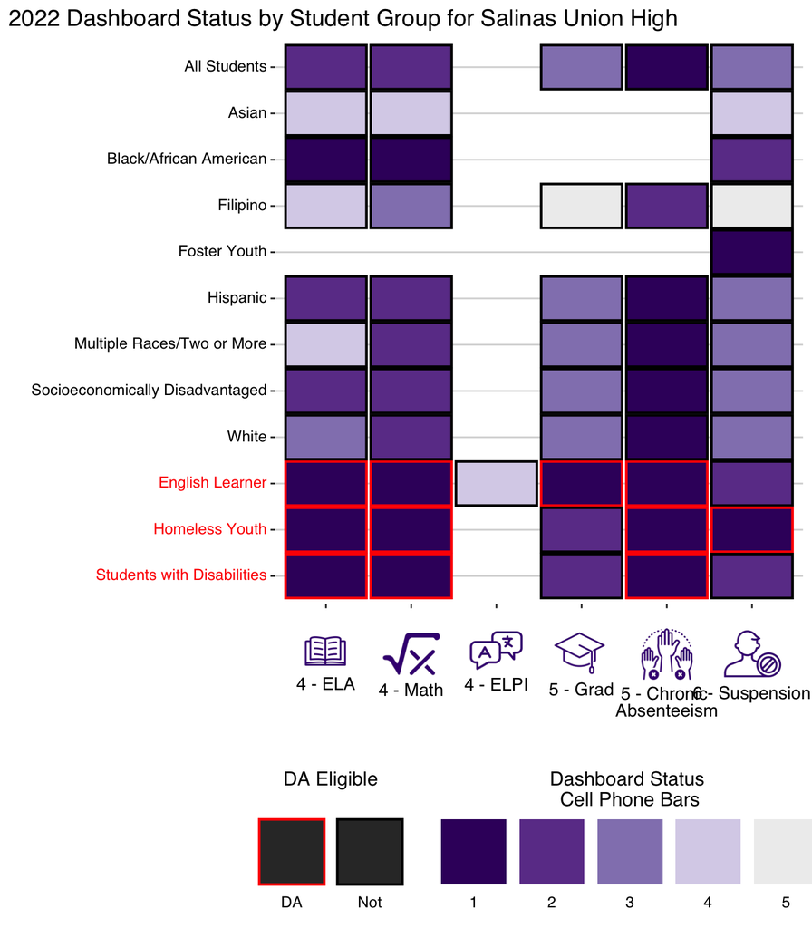

## Status Details for all Indicators

These graphs represent all of the indicators from the Dashboard and show how the student groups performed.

**Click here to display graphs**

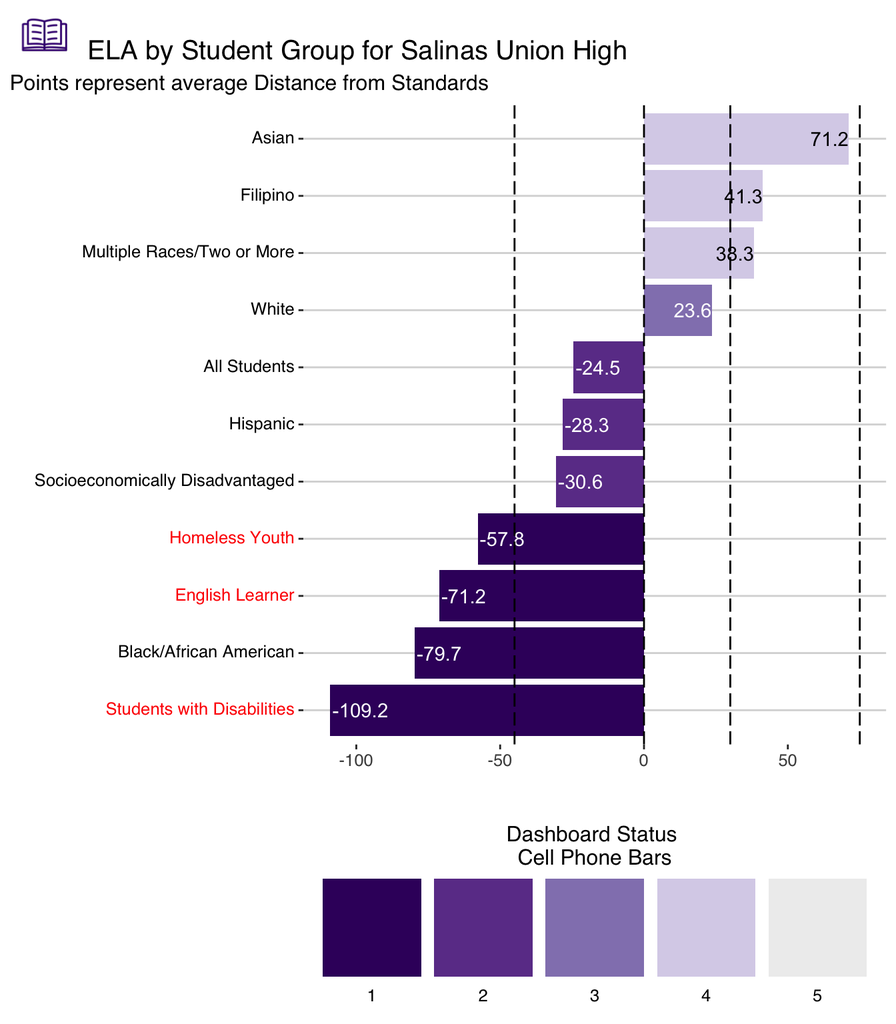

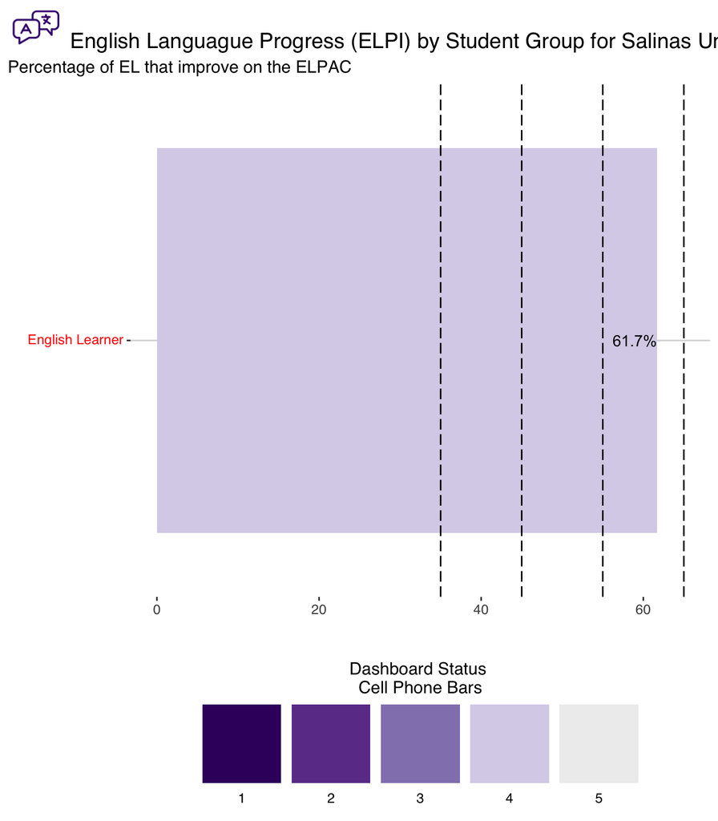

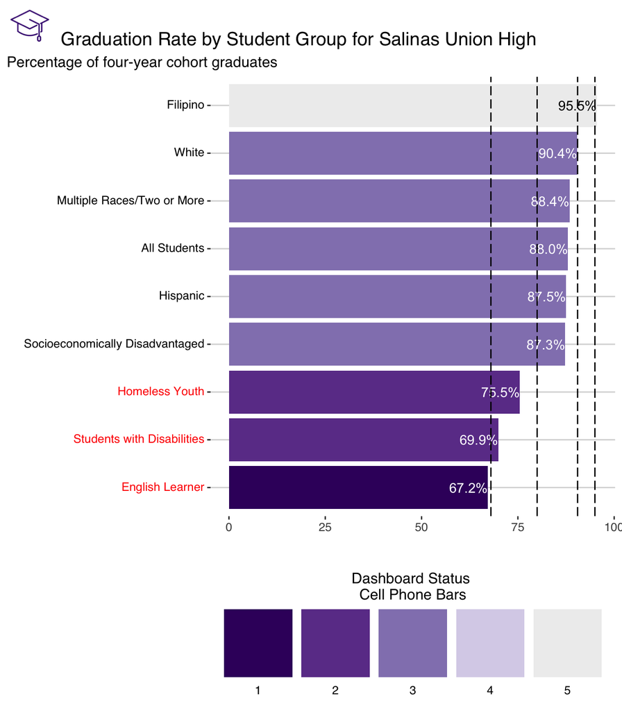

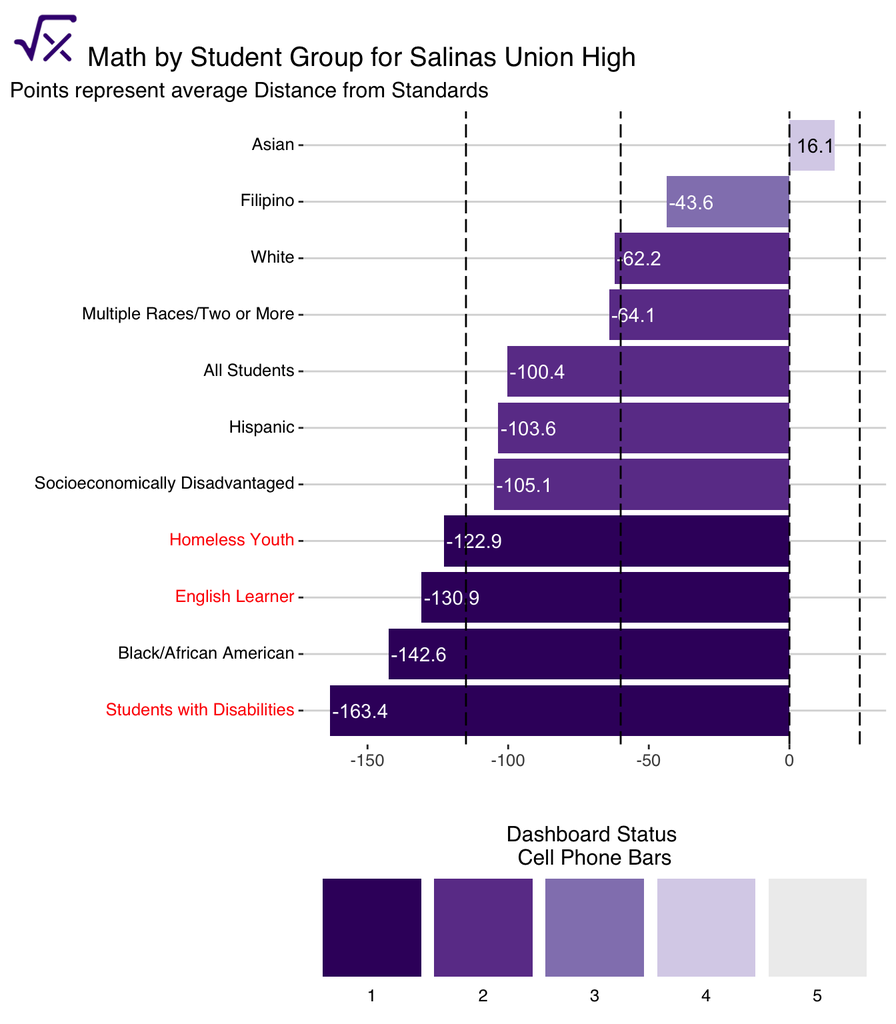

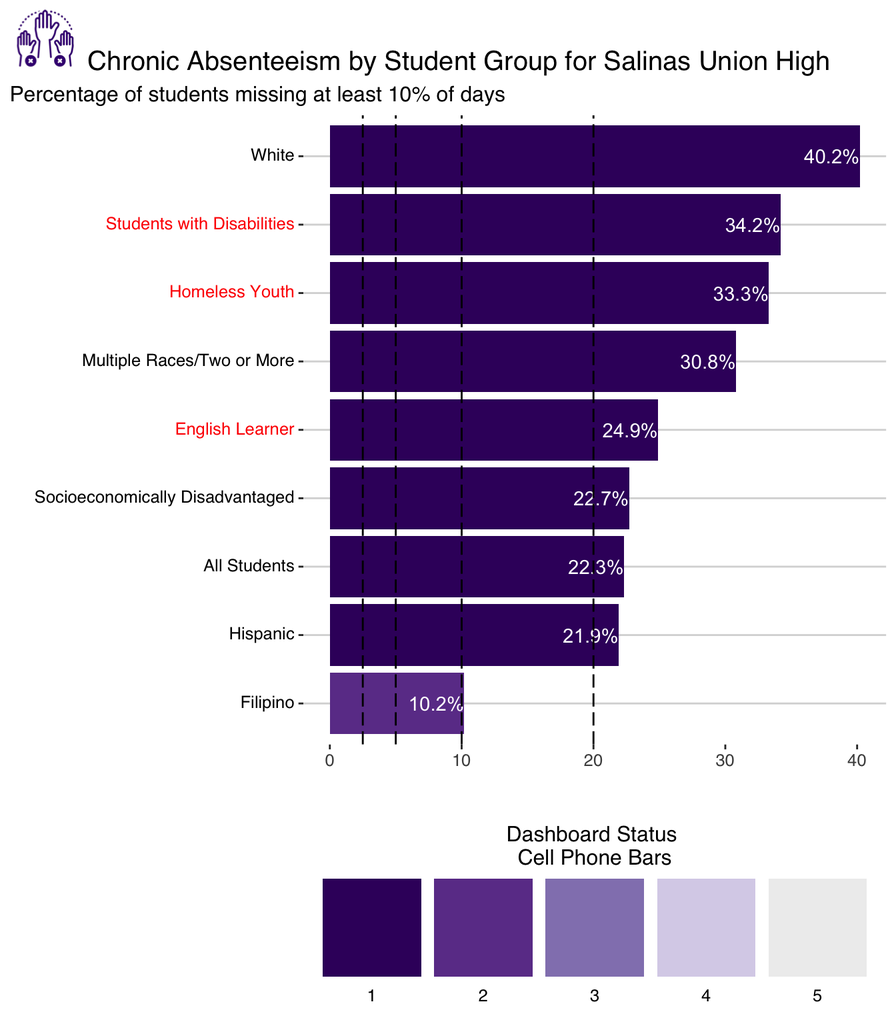

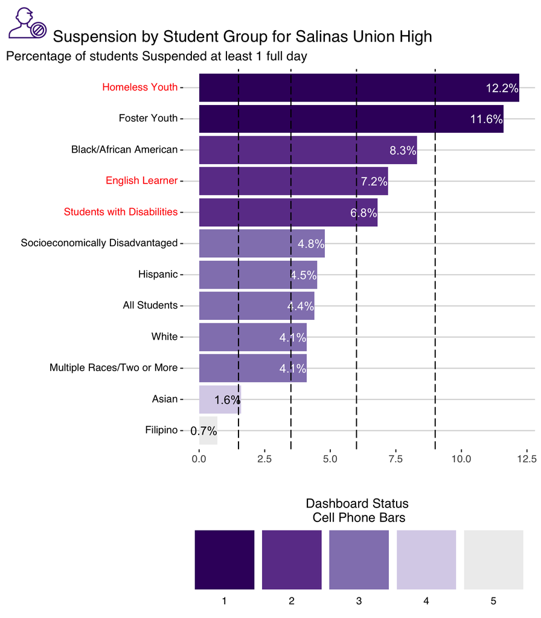

## Historical Graphs for Eligible Groups

These graphs represent all of the indicators from Priority Areas that qualified the district. They included all qualifying subgroups on each graph, whether this was a qualifying indicator or not, as well as the All Students group for comparisons.

**Click here to display graphs**

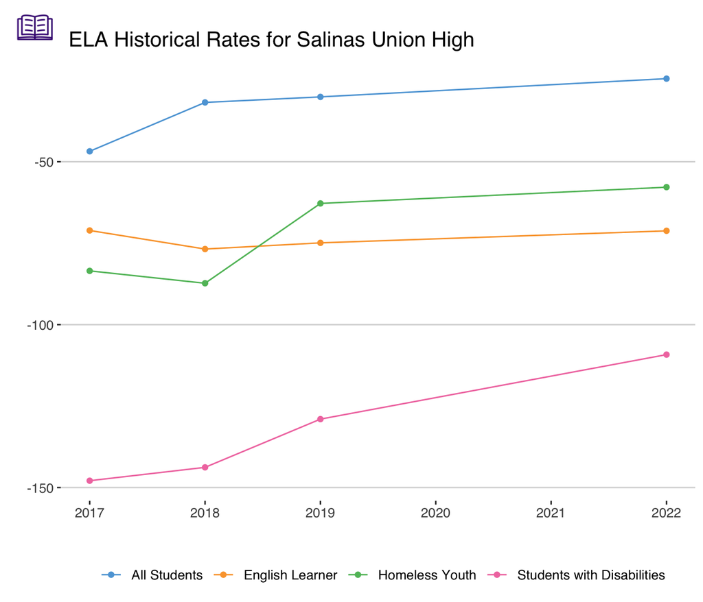

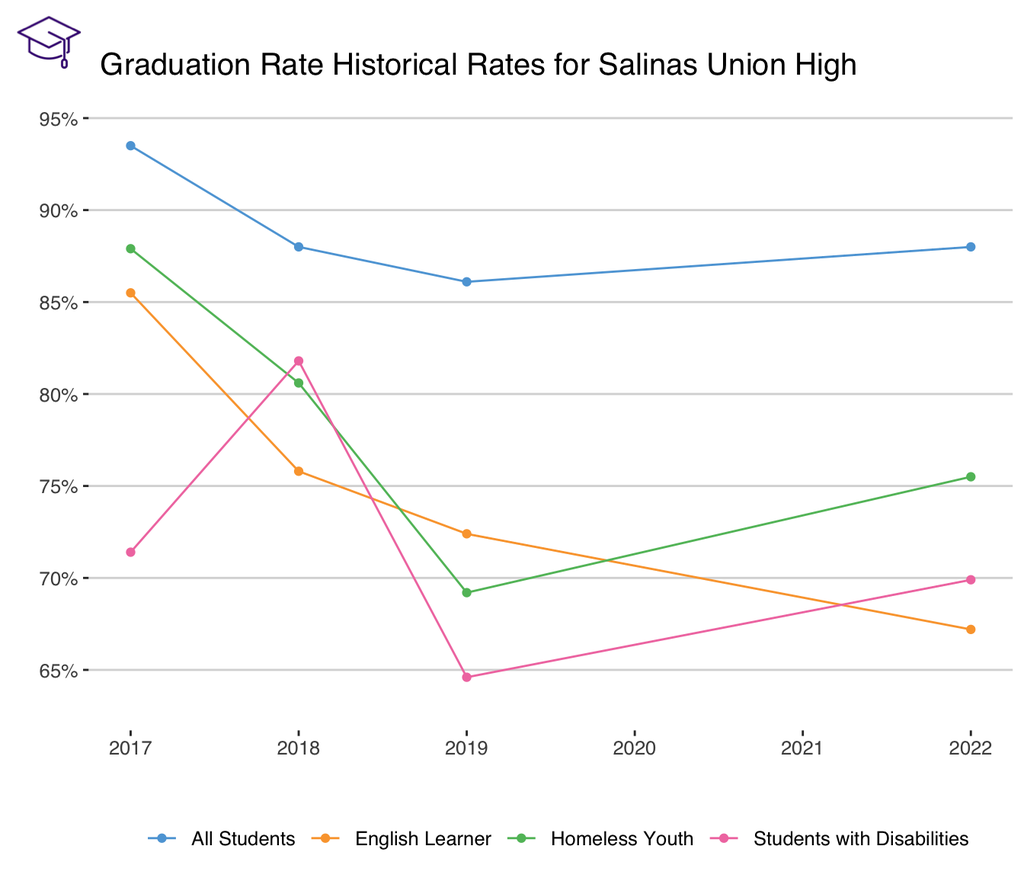

[figure not shown]

[figure not shown]

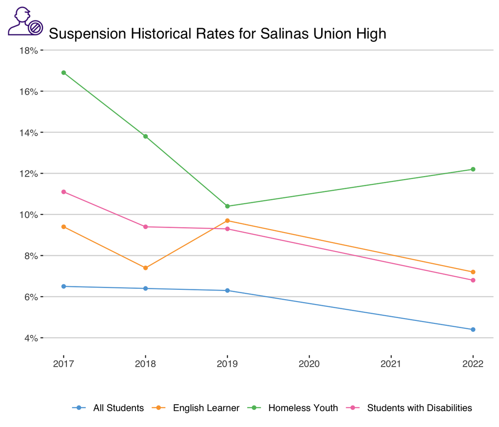

This section attempts to identify the limit on the number of students for relevant indicators to receive an orange or higher indicator in the 2023 Dashboard. The thresholds below are based on the Very Low status on the 5x5 grids used in 2019 and the number of students in the calculation in 2022. State policies may change and the student counts may shift.

| Student Group | Indicator | Current Status | Target Status for Orange | Change Needed | Number of Students (as applicable) |
| --- | --- | --- | --- | --- | --- |
| English Learner | ela | -71.2 | -68.2 | 3 |  |
| Homeless Youth | ela | -57.8 | -54.8 | 3 |  |
| Students with Disabilities | ela | -109.2 | -106.2 | 3 |  |
| English Learner | grad | 67.2 | 68 | 0.799999999999997 | 365 |
| English Learner | math | -130.9 | -127.9 | 3 |  |
| English Learner | chronic | 24.9 | 24.4 | -0.5 | 422 |
| Homeless Youth | chronic | 33.3 | 32.8 | -0.5 | 34 |
| Students with Disabilities | chronic | 34.2 | 33.7 | -0.5 | 191 |
| Homeless Youth | math | -122.9 | -119.9 | 3 |  |
| Students with Disabilities | math | -163.4 | -160.4 | 3 |  |

[output cut: 1 more lines]

The following sentences convey the same information as the table above in a different format for those who prefer written statements.

**Click here to display sentences**

[1] “*English Learner* student group should have 422 or less students **chroncially absent** based on the count in 2022 of 1730 to not be in Red.”  
[2] “*English Learner* student group should have an average of -68.2 from standard or higher based on the **ela** CAASPP exam to not be in Red.”  
[3] “*English Learner* student group should have 365 or more students **graduate** based on the count in 2022 of 536 to not be in Red.”  
[4] “*English Learner* student group should have an average of -127.9 from standard or higher based on the **math** CAASPP exam to not be in Red.”  
[5] “*Homeless Youth* student group should have 34 or less students **chroncially absent** based on the count in 2022 of 105 to not be in Red.”  
[6] “*Homeless Youth* student group should have an average of -54.8 from standard or higher based on the **ela** CAASPP exam to not be in Red.”  
[7] “*Homeless Youth* student group should have an average of -119.9 from standard or higher based on the **math** CAASPP exam to not be in Red.”  
[8] “*Homeless Youth* student group should have 26 or less students **suspended** based on the count in 2022 of 230 to not be in Red.”  
[9] “*Students with Disabilities* student group should have 191 or less students **chroncially absent** based on the count in 2022 of 568 to not be in Red.” [10] “*Students with Disabilities* student group should have an average of -106.2 from standard or higher based on the **ela** CAASPP exam to not be in Red.” [11] “*Students with Disabilities* student group should have an average of -160.4 from standard or higher based on the **math** CAASPP exam to not be in Red.”

This report was generated at 2023-01-05 09:13:21.

It was developed by [David Dobrowski](https://github.com/dobrowski) at the [Monterey County Office of Education](https://www.montereycoe.org/)